# Class 18 - In class exercises

Hari Subhash

Date created: 2019-05-08

### Task Set 1: For loop

Go here to check out the [basic elements of a for loop](https://puzhu.github.io/R4D/Classes/Class%2017/class17_slides.html#/a-common-recipe).

**TASK 1**: Load the gapminder dataset. Loop through its columns. If a column is numeric then store the output of the `summary()` command. If it is not numeric, then store NULL. Print the output.

```r
library(gapminder)
for(i in seq_along(gapminder)) {
  column <- gapminder[[i]]
  print(is.numeric(column))
  if(is.numeric(column)) {
    output <- summary(column)
  } else {
    output <- NULL
  }
}
```

```
[1] FALSE
[1] FALSE
[1] TRUE
[1] TRUE
[1] TRUE
[1] TRUE
```

```r
print(output)
```

```
    Min.  1st Qu.   Median     Mean  3rd Qu.     Max.
   241.2   1202.1   3531.8   7215.3   9325.5 113523.1
```

```r
##make your loop here
```

You can use `names()` to both get and set the names of a vector. The code below `gets` the names of the `mtcars` dataset.

```r
names(mtcars)
```

```
 [1] "mpg"  "cyl"  "disp" "hp"   "drat" "wt"   "qsec" "vs"   "am"   "gear" "carb"
```

In the code below I use `names()` to set the column headers of a copy of the `mtcars` dataset called `mtcars_2`. See the output to notice how the column headings have been changed.

```r
## create a copy of the mtcars data
mtcars_2 <- mtcars
names(mtcars_2) <- paste0(names(mtcars), "_2")
mtcars_2
```

|  | mpg_2 | cyl_2 | disp_2 | hp_2 | drat_2 | wt_2 | qsec_2 | vs_2 | am_2 | gear_2 | carb_2 |
| --- | --- | --- | --- | --- | --- | --- | --- | --- | --- | --- | --- |
| Mazda RX4 | 21.0 | 6 | 160.0 | 110 | 3.90 | 2.620 | 16.46 | 0 | 1 | 4 | 4 |
| Mazda RX4 Wag | 21.0 | 6 | 160.0 | 110 | 3.90 | 2.875 | 17.02 | 0 | 1 | 4 | 4 |
| Datsun 710 | 22.8 | 4 | 108.0 | 93 | 3.85 | 2.320 | 18.61 | 1 | 1 | 4 | 1 |
| Hornet 4 Drive | 21.4 | 6 | 258.0 | 110 | 3.08 | 3.215 | 19.44 | 1 | 0 | 3 | 1 |
| Hornet Sportabout | 18.7 | 8 | 360.0 | 175 | 3.15 | 3.440 | 17.02 | 0 | 0 | 3 | 2 |
| Valiant | 18.1 | 6 | 225.0 | 105 | 2.76 | 3.460 | 20.22 | 1 | 0 | 3 | 1 |
| Duster 360 | 14.3 | 8 | 360.0 | 245 | 3.21 | 3.570 | 15.84 | 0 | 0 | 3 | 4 |
| Merc 240D | 24.4 | 4 | 146.7 | 62 | 3.69 | 3.190 | 20.00 | 1 | 0 | 4 | 2 |
| Merc 230 | 22.8 | 4 | 140.8 | 95 | 3.92 | 3.150 | 22.90 | 1 | 0 | 4 | 2 |
| Merc 280 | 19.2 | 6 | 167.6 | 123 | 3.92 | 3.440 | 18.30 | 1 | 0 | 4 | 4 |

[output cut: 22 more lines]

**TASK 2**: Replicate the code to get `names()` of gapminder and append the string “_out" to each of them and set them as the names of the output vector you created in task 1.

```r
colNames <- names(gapminder)
colNames <-  paste0(colNames, '_out')
names(output) <- colNames
output
```

```
  country_out continent_out      year_out   lifeExp_out       pop_out gdpPercap_out
        241.2        1202.1        3531.8        7215.3        9325.5      113523.1
```

### Task Set 2: Functions

**Task 1**: Create a function called `square_greater()` that takes two arguments x and y that are numbers (i.e. atomic vectors of length one) and returns the square of whichever number is the greatest. Use `stopifnot(condition1, condition2)` to throw an error if any of the two input values are greater than 1 in length.

```r
##define your function here
square_greater <- function(x, y) {
  greater <- max(as.numeric(x), as.numeric(y))
  return(greater^2)
}
```

Test your function to make sure it works.

```r
##run this after you define your function
square_greater(x = 32, y = 87) ## this should work
```

```
[1] 7569
```

```r
square_greater(x = 3.2, y = "4") ## this should work
```

```
[1] 16
```

```r
square_greater(x = 23:45, y = 89) ## this should throw an error
```

```
[1] 7921
```

The `hist()` command is from base R and takes a numeric vector as its input. See the code below for an illustration using the `wt` column from the `mtcars` dataset.

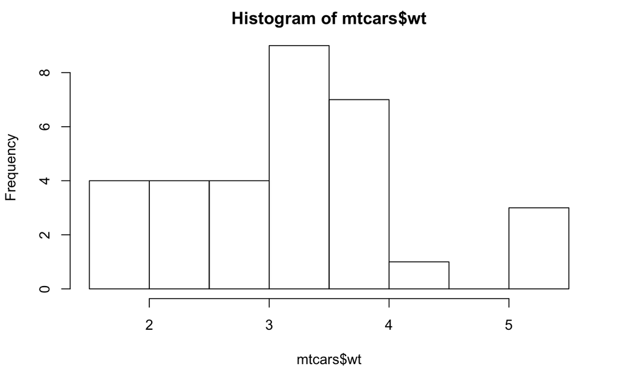

```r
hist(mtcars$wt)
```

**Task 2**: Create a function called `draw_hist()` that takes an atomic vector (of any length) as its input. If it numeric then use the `hist()` function from base to draw a histogram else return an error with a custom message of your choosing using `stop()`.

```r
##create your function
draw_hist <- function(v) {
  if (is.numeric(v)) {
    return(hist(v))
  }
  return(stop('Bad bad bad bad boy'))
}
```

Test your function to make sure it works.

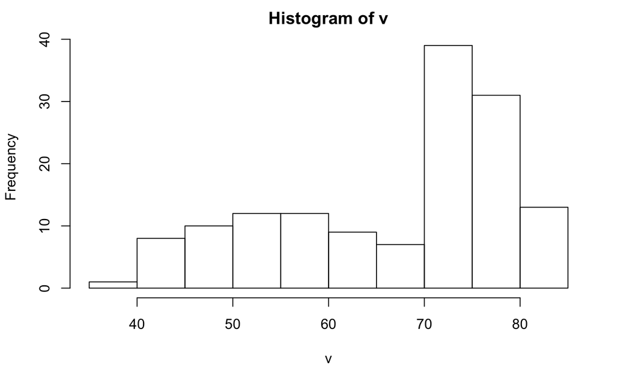

```r
library(tidyverse)
library(gapminder)
latest_gap <- gapminder %>%
  filter(year == max(year, na.rm = T))
draw_hist(pull(latest_gap, lifeExp)) ## this should plot a histogram of life expectancy
```

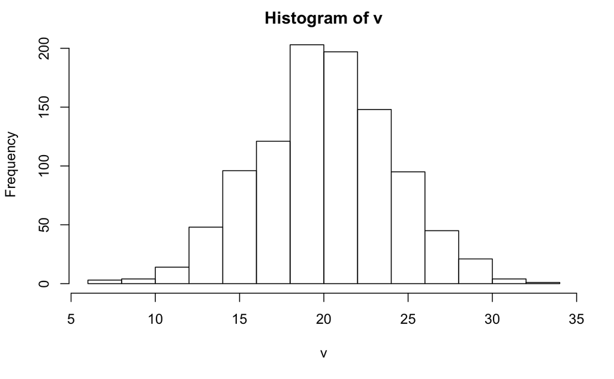

```r
draw_hist(rnorm(n = 1000, mean = 20, sd = 4)) ## this should plot a histogram of a numeric vector with mean 20 and std dev of 4
```

```r
draw_hist(pull(latest_gap, continent)) ## this should throw an error
```

```
Error in draw_hist(pull(latest_gap, continent)) : Bad bad bad bad boy
```